# Multiple Linear Regression - Predicting the Prices of house in Boston

INSOFE Lab

14th July 2018

- Objective - Build a multiple linear regression model using lm()

**NOTE** Before starting this assignment please remember to clear your environment, you can do that by running the following code chunk.

```r
rm(list = ls(all=TRUE))
```

# Agenda

- Get the data
- Explore the data
- Data Pre-processing
- Model the data
- Evaluation

# Reading & Understanding the Data

- Make sure the dataset is located in your current working directory

```r
housing_data <- read.csv(file = "HousingData.csv",header = T,sep = ',')
```

- Use the str() function to get a feel for the dataset.

```r
str(housing_data)
```

```
## 'data.frame':    500 obs. of  14 variables:
##  $ CRIM : num  0.00632 0.02731 0.02729 0.03237 0.06905 ...
##  $ ZN   : num  18 0 0 NA 0 0 12.5 12.5 12.5 12.5 ...
##  $ INDUS: num  2.31 7.07 7.07 2.18 2.18 ...
##  $ CHAS : int  0 0 0 0 0 0 0 0 0 0 ...
##  $ NOX  : num  0.538 0.469 0.469 0.458 0.458 ...
##  $ RM   : num  6.57 6.42 7.18 7 7.15 ...
##  $ AGE  : num  65.2 78.9 61.1 45.8 54.2 ...
##  $ DIS  : num  4.09 4.97 4.97 6.06 6.06 ...
##  $ RAD  : int  1 2 2 3 3 3 5 5 5 5 ...
##  $ TAX  : int  296 242 242 222 222 222 311 311 311 311 ...
##  $ PT   : num  15.3 17.8 17.8 18.7 18.7 ...
##  $ B    : num  NA 397 393 395 397 ...
##  $ LSTAT: num  4.98 9.14 4.03 2.94 5.33 ...
##  $ MV   : num  24 21.6 34.7 33.4 36.2 ...
```

```r
head(housing_data)
```

```
##      CRIM ZN INDUS CHAS   NOX    RM  AGE    DIS RAD TAX   PT      B LSTAT
## 1 0.00632 18  2.31    0 0.538 6.575 65.2 4.0900   1 296 15.3     NA  4.98
## 2 0.02731  0  7.07    0 0.469 6.421 78.9 4.9671   2 242 17.8 396.90  9.14
## 3 0.02729  0  7.07    0 0.469 7.185 61.1 4.9671   2 242 17.8 392.83  4.03
## 4 0.03237 NA  2.18    0 0.458 6.998 45.8 6.0622   3 222 18.7 394.63  2.94
## 5 0.06905  0  2.18    0 0.458 7.147 54.2 6.0622   3 222 18.7 396.90  5.33
## 6 0.02985  0  2.18    0 0.458 6.430 58.7 6.0622   3 222 18.7 394.12  5.21
##     MV
## 1 24.0
## 2 21.6
## 3 34.7
## 4 33.4
## 5 36.2
## 6 28.7
```

```r
tail(housing_data)
```

```
##        CRIM ZN INDUS CHAS   NOX    RM  AGE    DIS RAD TAX   PT      B
## 495 0.22438  0  9.69    0 0.585 6.027 79.7 2.4982   6 391 19.2 396.90
## 496 0.06263  0 11.93    0 0.573 6.593 69.1 2.4786   1 273 21.0 391.99
## 497 0.04527  0 11.93    0 0.573 6.120 76.7 2.2875   1 273 21.0 396.90
## 498 0.06076  0 11.93    0    NA 6.976 91.0 2.1675   1 273 21.0 396.90
## 499 0.10959  0 11.93    0 0.573 6.794 89.3 2.3889   1 273 21.0 393.45
## 500 0.04741  0 11.93    0 0.573 6.030 80.8 2.5050   1 273 21.0 396.90
##     LSTAT   MV
## 495 14.33 16.8
## 496  9.67 22.4
## 497  9.08 20.6
## 498  5.64 23.9
## 499  6.48 22.0
## 500  7.88 11.9
```

- So, let’s get ready to predict the prices of houses!!

# Exploratory Analysis

## Summary Statistics

- Understand the distribution of various variables in the datset using the “summary()” function

```r
summary(housing_data)
```

```
##       CRIM                ZN             INDUS            CHAS
##  Min.   : 0.00632   Min.   :  0.00   Min.   : 0.46   Min.   :0.00000
##  1st Qu.: 0.08199   1st Qu.:  0.00   1st Qu.: 5.19   1st Qu.:0.00000
##  Median : 0.26169   Median :  0.00   Median : 9.69   Median :0.00000
##  Mean   : 3.65532   Mean   : 11.25   Mean   :11.12   Mean   :0.07071
##  3rd Qu.: 3.67822   3rd Qu.: 12.50   3rd Qu.:18.10   3rd Qu.:0.00000
##  Max.   :88.97620   Max.   :100.00   Max.   :27.74   Max.   :1.00000
##  NA's   :7          NA's   :7        NA's   :4       NA's   :5
##       NOX               RM             AGE              DIS
##  Min.   :0.3850   Min.   :3.561   Min.   :  2.90   Min.   : 1.130
##  1st Qu.:0.4482   1st Qu.:5.885   1st Qu.: 44.40   1st Qu.: 2.097
##  Median :0.5380   Median :6.209   Median : 77.70   Median : 3.191
##  Mean   :0.5538   Mean   :6.289   Mean   : 68.58   Mean   : 3.785
##  3rd Qu.:0.6240   3rd Qu.:6.629   3rd Qu.: 94.10   3rd Qu.: 5.118
##  Max.   :0.8710   Max.   :8.780   Max.   :100.00   Max.   :12.127
##  NA's   :6        NA's   :4       NA's   :3        NA's   :4
##       RAD              TAX              PT              B
##  Min.   : 1.000   Min.   :187.0   Min.   :12.60   Min.   :  0.32
##  1st Qu.: 4.000   1st Qu.:279.0   1st Qu.:17.40   1st Qu.:375.30
##  Median : 5.000   Median :330.0   Median :19.10   Median :391.34
##  Mean   : 9.539   Mean   :407.5   Mean   :18.47   Mean   :356.60
##  3rd Qu.:24.000   3rd Qu.:666.0   3rd Qu.:20.20   3rd Qu.:396.21
##  Max.   :24.000   Max.   :711.0   Max.   :22.00   Max.   :396.90
##  NA's   :5        NA's   :6       NA's   :9       NA's   :4
##      LSTAT             MV
##  Min.   : 1.73   Min.   : 5.00
##  1st Qu.: 6.95   1st Qu.:17.07
##  Median :11.43   Median :21.20
##  Mean   :12.65   Mean   :22.56
##  3rd Qu.:16.95   3rd Qu.:25.00
##  Max.   :37.97   Max.   :50.00
##  NA's   :6
```

## Study the NA values per column

```r
data.frame(colSums(is.na(housing_data)))
```

```
##       colSums.is.na.housing_data..
## CRIM                             7
## ZN                               7
## INDUS                            4
## CHAS                             5
## NOX                              6
## RM                               4
## AGE                              3
## DIS                              4
## RAD                              5
## TAX                              6
## PT                               9
## B                                4
## LSTAT                            6
## MV                               0
```

## Scatter Plots

- A few bi-variate relationships are plotted below, but you are encouraged to explore the dataset in more detail

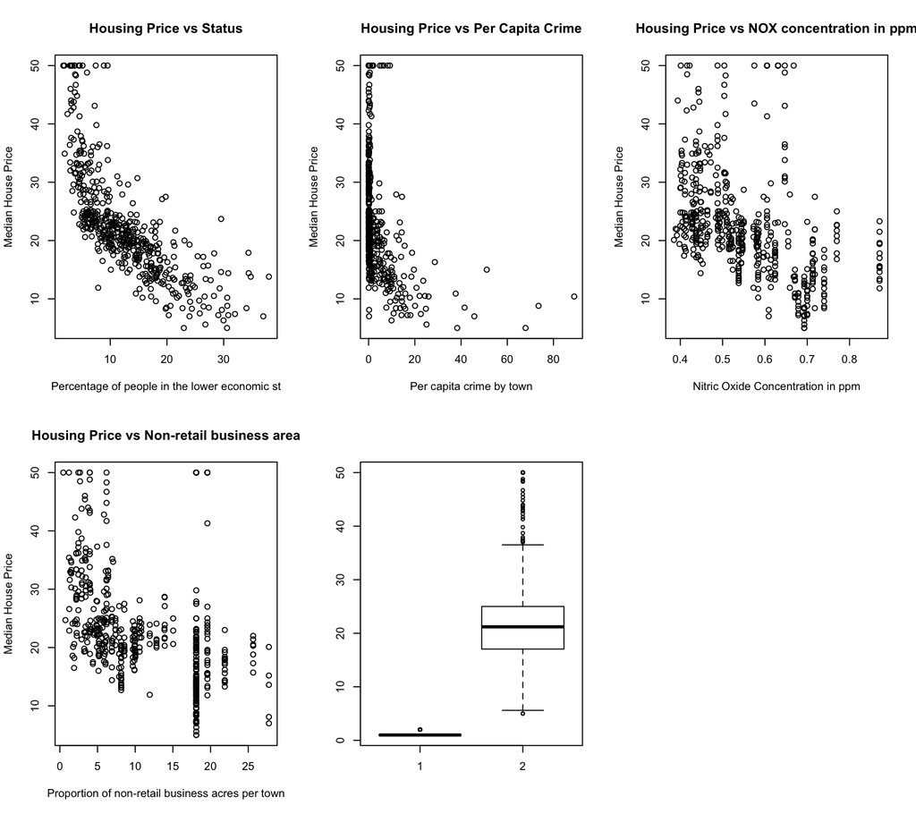

```r
par(mfrow = c(2,3))

plot(housing_data$LSTAT, housing_data$MV, ylab = "Median House Price", xlab = "Percentage of people in the lower economic st", main = "Housing Price vs Status")

plot(housing_data$CRIM, housing_data$MV, ylab = "Median House Price", xlab = "Per capita crime by town", main = "Housing Price vs Per Capita Crime")

plot(housing_data$NOX, housing_data$MV, ylab = "Median House Price", xlab = "Nitric Oxide Concentration in ppm", main = "Housing Price vs NOX concentration in ppm")

plot(housing_data$INDUS, housing_data$MV, ylab = "Median House Price", xlab = "Proportion of non-retail business acres per town", main = "Housing Price vs Non-retail business area")

boxplot(as.factor(housing_data$CHAS),housing_data$MV,names =levels(housing_data$CHAS))
```

- Report your observation looking at above plots

## Correlation Plot

- Let’s have a look at the various correlations between the variables in the dataset

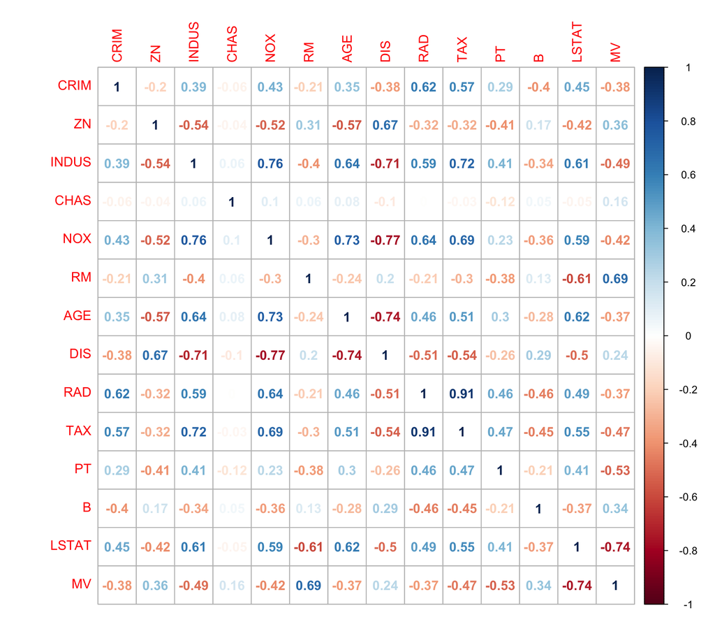

```r
#install.packages("corrplot")
library(corrplot)
correlation_XPairwise = cor(housing_data)
corrplot(cor(housing_data, use = "complete.obs"), method = "number") # If use is "complete.obs" then missing values are handled by casewise deletion
```

```r
# Write the pairwise correlation matrix to a csv file for later analysis
write.table(correlation_XPairwise,file="pairwiseCorrelations1.csv",row.names=FALSE,col.names=FALSE,sep=",")
## Observation find a  mistake in the plot below
```

- Observe the variables which are highly correlated (RAD and TAX)

# Data Pre-processing

- Today we will impute missing values and standardize the data **after** splitting the data into train and test sets

## Convert the data type into require format

```r
housing_data$CHAS = as.factor(housing_data$CHAS)
```

## Train/Test Split

- 70/30 - Train/Test split

```r
set.seed(123)

# the "sample()" function helps us to randomly sample 70% of the row indices of the dataset

train_rows <- sample(x = 1:nrow(housing_data), size = 0.7*nrow(housing_data))

# We use the above indices to subset the train and test sets from the data

train_data <- housing_data[train_rows, ]

test_data <- housing_data[-train_rows, ]

dim(train_data)
```

```
## [1] 350  14
```

```r
dim(test_data)
```

```
## [1] 150  14
```

## Columnwise Missing values in Housing Data

```r
cat("Missing Data Per Columns in Train Data \n")
```

```
## Missing Data Per Columns in Train Data
```

```r
colSums(is.na(train_data))
```

```
##  CRIM    ZN INDUS  CHAS   NOX    RM   AGE   DIS   RAD   TAX    PT     B
##     4     5     3     5     4     3     1     3     2     3     6     3
## LSTAT    MV
##     4     0
```

```r
cat("Missing Data Per Columns in Test Data \n")
```

```
## Missing Data Per Columns in Test Data
```

```r
colSums(is.na(test_data))
```

```
##  CRIM    ZN INDUS  CHAS   NOX    RM   AGE   DIS   RAD   TAX    PT     B
##     3     2     1     0     2     1     2     1     3     3     3     1
## LSTAT    MV
##     2     0
```

## Missing Values Imputation

- Find out the number of missing values in the dataset
- Impute the missing values using the “preProcess()” function in conjunction with the “medianImpute” method

```r
#install.packages("caret")
library(caret)
sum(is.na(train_data))
```

```
## [1] 46
```

```r
sum(is.na(test_data))
```

```
## [1] 24
```

```r
imputer_values <- preProcess(x = train_data[, !names(train_data) %in% c("CHAS")], method = "medianImpute")

train_data[, !names(train_data) %in% c("CHAS")] <- predict(object = imputer_values, newdata = train_data[, !names(train_data) %in% c("CHAS")])
sum(is.na(train_data[, !names(train_data) %in% c("CHAS")]))
```

```
## [1] 0
```

```r
test_data[, !names(train_data) %in% c("CHAS")] <- predict(object = imputer_values, newdata = test_data[, !names(train_data) %in% c("CHAS")])

sum(is.na(test_data[, !names(train_data) %in% c("CHAS")]))
```

```
## [1] 0
```

```r
sum(is.na(train_data))
```

```
## [1] 5
```

```r
sum(is.na(test_data))
```

```
## [1] 0
```

## Imputing the Categorical attributes with the Mode

```r
library(DMwR)
centralValue(train_data$CHAS)
```

```
## [1] "0"
```

```r
train_data = centralImputation(train_data)
```

## Sanity Checking for the missin gvalues in both train and test

```r
cat("Missing Data Per Columns in Train Data after imputation \n")
```

```
## Missing Data Per Columns in Train Data after imputation
```

```r
colSums(is.na(train_data))
```

```
##  CRIM    ZN INDUS  CHAS   NOX    RM   AGE   DIS   RAD   TAX    PT     B
##     0     0     0     0     0     0     0     0     0     0     0     0
## LSTAT    MV
##     0     0
```

```r
cat("Missing Data Per Columns in Test Data after imputation \n")
```

```
## Missing Data Per Columns in Test Data after imputation
```

```r
colSums(is.na(test_data))
```

```
##  CRIM    ZN INDUS  CHAS   NOX    RM   AGE   DIS   RAD   TAX    PT     B
##     0     0     0     0     0     0     0     0     0     0     0     0
## LSTAT    MV
##     0     0
```

## Standardizing the Data

- We will use the Caret pakcage to standardize the data after the split using the **“preProcess()”** function
- It saves the metrics such as mean and standard deviation used for calculating the standardized value by creating a model object
- We can then use the model object in the **“predict()”** function to standardize any other unseen dataset with the same distribuiton and variables

```r
# The "preProcess()" function creates a model object required for standardizing unseen data

# Do not standardize the target variable

std_model <- preProcess(train_data[, !names(train_data) %in% c("MV","CHAS")], method = c("center", "scale"))
std_model
```

```
## Created from 350 samples and 12 variables
##
## Pre-processing:
##   - centered (12)
##   - ignored (0)
##   - scaled (12)
```

```r
# The predict() function is used to standardize any other unseen data

train_data[, !names(train_data) %in% c("MV","CHAS")] <- predict(object = std_model, newdata = train_data[, !names(train_data) %in% c("MV","CHAS")])

test_data[, !names(train_data) %in% c("MV","CHAS")] <- predict(object = std_model, newdata = test_data[, !names(train_data) %in% c("MV","CHAS")])

summary(train_data)
```

```
##       CRIM                ZN              INDUS         CHAS
##  Min.   :-0.41423   Min.   :-0.4907   Min.   :-1.4819   0:327
##  1st Qu.:-0.40669   1st Qu.:-0.4907   1st Qu.:-0.8361   1: 23
##  Median :-0.38643   Median :-0.4907   Median :-0.3285
##  Mean   : 0.00000   Mean   : 0.0000   Mean   : 0.0000
##  3rd Qu.:-0.01892   3rd Qu.: 0.1712   3rd Qu.: 1.0300
##  Max.   : 9.84045   Max.   : 3.5826   Max.   : 2.4027
##       NOX                RM               AGE               DIS
##  Min.   :-1.4310   Min.   :-3.0179   Min.   :-2.2800   Min.   :-1.2296
##  1st Qu.:-0.8896   1st Qu.:-0.5983   1st Qu.:-0.8455   1st Qu.:-0.8102
##  Median :-0.2708   Median :-0.1373   Median : 0.3387   Median :-0.2996
##  Mean   : 0.0000   Mean   : 0.0000   Mean   : 0.0000   Mean   : 0.0000
##  3rd Qu.: 0.6229   3rd Qu.: 0.4748   3rd Qu.: 0.9058   3rd Qu.: 0.6208
##  Max.   : 2.7455   Max.   : 3.4325   Max.   : 1.1194   Max.   : 3.7516
##       RAD               TAX                PT                B
##  Min.   :-0.9698   Min.   :-1.2858   Min.   :-2.6755   Min.   :-3.9444
##  1st Qu.:-0.6200   1st Qu.:-0.7384   1st Qu.:-0.4740   1st Qu.: 0.1968
##  Median :-0.5034   Median :-0.4350   Median : 0.2369   Median : 0.3770
##  Mean   : 0.0000   Mean   : 0.0000   Mean   : 0.0000   Mean   : 0.0000
##  3rd Qu.:-0.1536   3rd Qu.: 1.5643   3rd Qu.: 0.8102   3rd Qu.: 0.4258
##  Max.   : 1.7120   Max.   : 1.8320   Max.   : 1.6358   Max.   : 0.4344
##      LSTAT               MV
##  Min.   :-1.4677   Min.   : 5.00
##  1st Qu.:-0.7844   1st Qu.:16.80
##  Median :-0.2105   Median :21.40
##  Mean   : 0.0000   Mean   :22.92
##  3rd Qu.: 0.5460   3rd Qu.:26.57
##  Max.   : 3.3522   Max.   :50.00
```

# Modelling the Data

## Basic Model

- The “.” adds all the variables other than the response variable while building the model.

```r
# Capturing the Start and end time taken for model building
start_time = Sys.time()
model_basic <- lm(formula = MV~. , data =(train_data))
end_time = Sys.time()
time_taken = end_time - start_time
time_taken
```

```
## Time difference of 0.01581097 secs
```

```r
cat(end_time - start_time)
```

```
## 0.01581097
```

## Model Summary

```r
summary(model_basic)
```

```
##
## Call:
## lm(formula = MV ~ ., data = (train_data))
##
## Residuals:
##      Min       1Q   Median       3Q      Max
## -19.0313  -2.9807  -0.7418   1.6938  27.0101
##
## Coefficients:
##             Estimate Std. Error t value Pr(>|t|)
## (Intercept) 22.67362    0.28090  80.719  < 2e-16 ***
## CRIM        -1.10766    0.36978  -2.996 0.002943 **
## ZN           1.04389    0.40939   2.550 0.011221 *
## INDUS        0.47464    0.55061   0.862 0.389288
## CHAS1        3.76661    1.13086   3.331 0.000962 ***
## NOX         -2.11862    0.55753  -3.800 0.000172 ***
## RM           3.31251    0.39694   8.345 1.87e-15 ***
## AGE         -0.09802    0.47679  -0.206 0.837244
## DIS         -2.82894    0.54168  -5.223 3.10e-07 ***
## RAD          2.62319    0.68789   3.813 0.000163 ***
## TAX         -1.80083    0.72998  -2.467 0.014124 *
## PT          -1.89999    0.36441  -5.214 3.24e-07 ***
## B            1.12080    0.31248   3.587 0.000385 ***
## LSTAT       -3.69797    0.48247  -7.665 1.94e-13 ***
## ---
## Signif. codes:  0 '***' 0.001 '**' 0.01 '*' 0.05 '.' 0.1 ' ' 1
##
## Residual standard error: 5.068 on 336 degrees of freedom
## Multiple R-squared:  0.7445, Adjusted R-squared:  0.7346
## F-statistic:  75.3 on 13 and 336 DF,  p-value: < 2.2e-16
```

```r
df_residuals =model_basic$residuals
df_residuals
```

[output not shown]

[output cut: 85 more lines]

[output not shown]

```r
Residuals = function(model,data,target){
    predicted = predict(model,data)
    residuals = target - predicted
    return (residuals)
}
dfResiduals = Residuals(model_basic,train_data,train_data$MV)
```

```r
summary(dfResiduals)
```

```
##     Min.  1st Qu.   Median     Mean  3rd Qu.     Max.
## -19.0313  -2.9807  -0.7418   0.0000   1.6938  27.0101
```

## Standard Error of the Residuals

```r
SE_residuals =function(residuals,numberofparameters){
  squareOfResiduals = residuals^2
  sumOfResiduals = sum(squareOfResiduals)
  deg_of_freedom = length(residuals)-(numberofparameters)-1
  standardErrorResiduals = sqrt(sumOfResiduals/deg_of_freedom)
  cat("Residual standard error:",standardErrorResiduals," on",deg_of_freedom," degrees of freedom")
}
```

```r
standardErrorResiduals = SE_residuals(dfResiduals,13)
```

```
## Residual standard error: 5.067843  on 336  degrees of freedom
```

## Adjusted R squared

```r
Multiple_Adjusted_Rsquared = function(data,model,numberofparameters,target){
  yhat = predict(model,data)
  y = target

  multiple_Rsquared = round(1 - sum((y-yhat)^2)/sum((y-mean(y))^2),digits=4)

  cat("\n Mutliple R Squared :", multiple_Rsquared)
  adjustedRsquared = 1-(1-multiple_Rsquared)*((nrow(data)-1)/(nrow(data)-(numberofparameters)-1))
  cat("\n Adjusted R Square: ",round(adjustedRsquared,digits = 4))
}
Multiple_Adjusted_Rsquared(train_data,model_basic,13,train_data$MV)
```

```
##
##  Mutliple R Squared : 0.7445
##  Adjusted R Square:  0.7346
```

- Question: How good is the model?
- A basic assessment of the model can be obtained by reading off the R^2 (and adjusted R^2) values.
- Caution : A good R^2 value alone can be misleading.
- Question: Is the model significant?
- Important : Both model significance as well as significance of the individual coefficients need to be considered.

## Residual Plots

- Interpreting the diagnostic plots to check for the linear regression assumptions

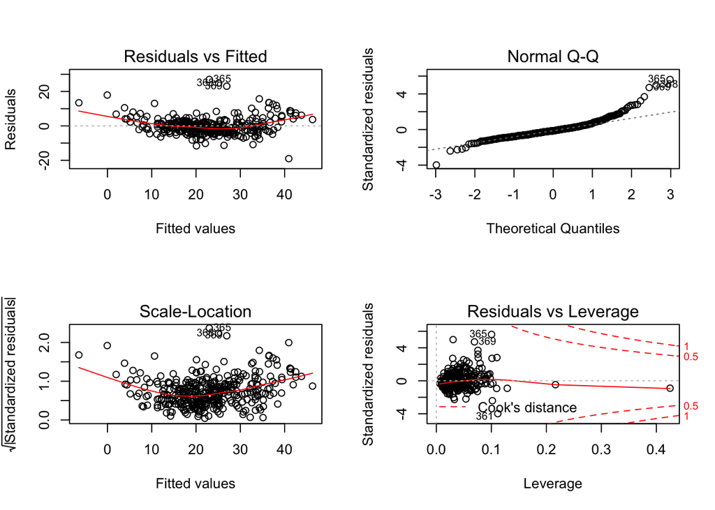

```r
par(mfrow = c(2,2))

plot(model_basic)
```

# Influential Observations

## Leverage

```r
#install.packages("car")
library(car)
```

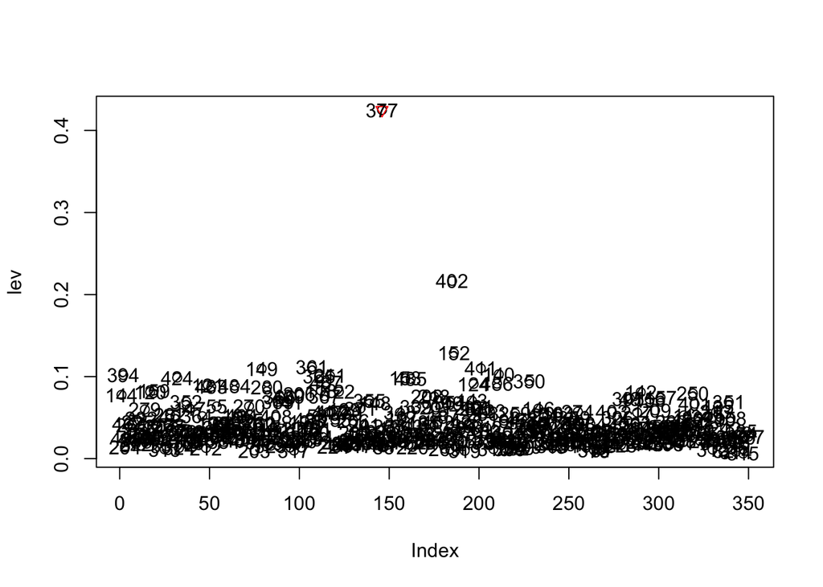

```r
lev= hat(model.matrix(model_basic))
plot(lev)
hlev = which(lev>0.3)
max=as.numeric(which.max(lev))
points(max,lev[max],col='red', pch=6)
text(lev,labels = rownames(train_data))
```

- Suppose we would like to remove records with leverage values greater than 0.3

```r
train_data[lev>0.3,]
```

```
##         CRIM         ZN   INDUS CHAS     NOX        RM       AGE       DIS
## 377 9.840447 -0.4907247 1.02998    0 1.02677 0.9146159 0.8358079 -1.099645
##          RAD      TAX        PT         B     LSTAT   MV
## 377 1.712033 1.564278 0.8102231 0.4344438 0.6489214 10.4
```

```r
train_data_lev<-train_data[-(lev>0.3),]
dim(train_data_lev)
```

```
## [1] 349  14
```

```r
## Method: Convention - If there are n data points and p parameters, then threshold can be taken a 3*p/n
 # lev_threshold <- 3*length(model_basic$coefficients)/length(lev)
 # train_data[which(lev>lev_threshold)]
 # length(train[lev>lev_threshold,])
```

# Cook’s distance

- Identifying influential observations and handling them

```r
# Identify records with high Cook's distance

cook = cooks.distance(model_basic)
plot(cook,ylab="Cook's distances")
max=as.numeric(which.max(cook))
max
```

```
## [1] 111
```

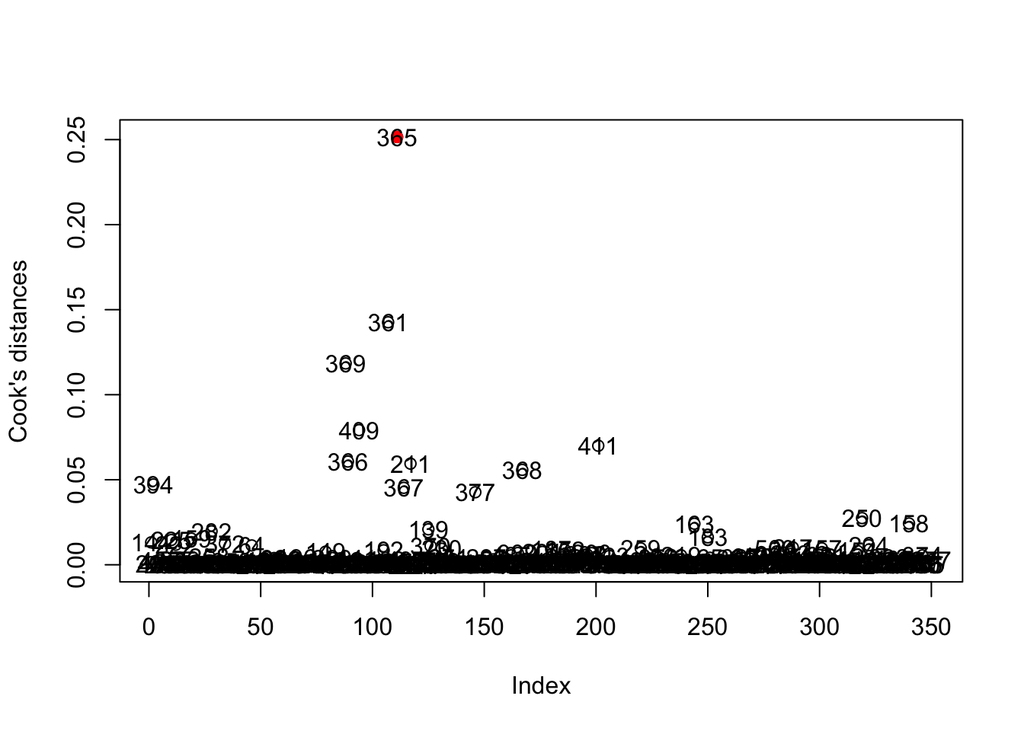

```r
points(max,cook[max],col='red', pch=19)
text(seq(1:nrow(train_data)),cook,labels = rownames(train_data))
```

```r
train_cook<-train_data_lev[-max,]
dim(train_cook)
```

```
## [1] 348  14
```

```r
model_basic2 <- lm(formula = MV~. , data = train_cook)
summary(model_basic2)
```

```
##
## Call:
## lm(formula = MV ~ ., data = train_cook)
##
## Residuals:
##      Min       1Q   Median       3Q      Max
## -19.1389  -2.9562  -0.7472   1.8331  26.8385
##
## Coefficients:
##             Estimate Std. Error t value Pr(>|t|)
## (Intercept) 22.64735    0.28198  80.314  < 2e-16 ***
## CRIM        -1.08738    0.36994  -2.939 0.003518 **
## ZN           1.03657    0.40995   2.529 0.011915 *
## INDUS        0.49249    0.56777   0.867 0.386338
## CHAS1        3.82335    1.13235   3.376 0.000821 ***
## NOX         -2.25787    0.56549  -3.993 8.03e-05 ***
## RM           3.31944    0.39686   8.364 1.66e-15 ***
## AGE         -0.04625    0.47822  -0.097 0.923018
## DIS         -2.84397    0.54166  -5.251 2.70e-07 ***
## RAD          2.66298    0.69098   3.854 0.000139 ***
## TAX         -1.79111    0.74528  -2.403 0.016795 *
## PT          -1.86103    0.36542  -5.093 5.91e-07 ***
## B            1.09441    0.31291   3.498 0.000533 ***
## LSTAT       -3.77433    0.48524  -7.778 9.23e-14 ***
## ---
## Signif. codes:  0 '***' 0.001 '**' 0.01 '*' 0.05 '.' 0.1 ' ' 1
##
## Residual standard error: 5.066 on 334 degrees of freedom
## Multiple R-squared:  0.7456, Adjusted R-squared:  0.7357
## F-statistic:  75.3 on 13 and 334 DF,  p-value: < 2.2e-16
```

- Observation: Adjusted R^2 did not change much

# stepAIC model

- “stepAIC()” is a function in the MASS package
- stepAIC uses AIC (Akaike information criterion) to either drop variables (“backward” direction) or add variables (“forward” direction) from the model

```r
library(MASS)

model_aic <- stepAIC(model_basic2, direction = "both",trace=TRUE)
```

```
## Start:  AIC=1143.07
## MV ~ CRIM + ZN + INDUS + CHAS + NOX + RM + AGE + DIS + RAD +
##     TAX + PT + B + LSTAT
##
##         Df Sum of Sq     RSS    AIC
## - AGE    1      0.24  8573.6 1141.1
## - INDUS  1     19.31  8592.7 1141.8
## <none>                8573.4 1143.1
## - TAX    1    148.25  8721.7 1147.0
## - ZN     1    164.11  8737.5 1147.7
## - CRIM   1    221.77  8795.2 1150.0
## - CHAS   1    292.64  8866.0 1152.8
## - B      1    314.00  8887.4 1153.6
## - RAD    1    381.25  8954.7 1156.2
## - NOX    1    409.22  8982.6 1157.3
## - PT     1    665.77  9239.2 1167.1
## - DIS    1    707.64  9281.0 1168.7
## - LSTAT  1   1553.04 10126.4 1199.0
## - RM     1   1795.85 10369.3 1207.2
##
## Step:  AIC=1141.08
## MV ~ CRIM + ZN + INDUS + CHAS + NOX + RM + DIS + RAD + TAX +
##     PT + B + LSTAT
##
##         Df Sum of Sq     RSS    AIC
## - INDUS  1     19.27  8592.9 1139.9
## <none>                8573.6 1141.1
## + AGE    1      0.24  8573.4 1143.1
## - TAX    1    148.95  8722.6 1145.1
## - ZN     1    167.74  8741.4 1145.8
## - CRIM   1    221.71  8795.4 1148.0
## - CHAS   1    292.51  8866.2 1150.8
## - B      1    314.36  8888.0 1151.6
## - RAD    1    384.27  8957.9 1154.3
## - NOX    1    444.94  9018.6 1156.7
## - PT     1    668.66  9242.3 1165.2
## - DIS    1    776.63  9350.3 1169.2
## - LSTAT  1   1757.42 10331.1 1204.0
## - RM     1   1860.19 10433.8 1207.4
##
## Step:  AIC=1139.86
## MV ~ CRIM + ZN + CHAS + NOX + RM + DIS + RAD + TAX + PT + B +
##     LSTAT
##
##         Df Sum of Sq     RSS    AIC
## <none>                8592.9 1139.9
## + INDUS  1     19.27  8573.6 1141.1
## + AGE    1      0.20  8592.7 1141.8
## - TAX    1    132.37  8725.3 1143.2
## - ZN     1    160.16  8753.1 1144.3
## - CRIM   1    228.85  8821.8 1147.0
## - CHAS   1    310.65  8903.6 1150.2
## - B      1    311.25  8904.2 1150.2
## - RAD    1    366.76  8959.7 1152.4
## - NOX    1    429.69  9022.6 1154.8
## - PT     1    651.69  9244.6 1163.3
## - DIS    1    890.60  9483.5 1172.2
## - LSTAT  1   1738.54 10331.5 1202.0
## - RM     1   1840.92 10433.8 1205.4
```

```r
summary(model_aic)
```

```
##
## Call:
## lm(formula = MV ~ CRIM + ZN + CHAS + NOX + RM + DIS + RAD + TAX +
##     PT + B + LSTAT, data = train_cook)
##
## Residuals:
##      Min       1Q   Median       3Q      Max
## -19.0582  -3.0302  -0.7556   1.7897  26.8489
##
## Coefficients:
##             Estimate Std. Error t value Pr(>|t|)
## (Intercept)  22.6380     0.2813  80.488  < 2e-16 ***
## CRIM         -1.1011     0.3681  -2.991 0.002982 **
## ZN            1.0144     0.4053   2.503 0.012805 *
## CHAS1         3.9196     1.1246   3.485 0.000557 ***
## NOX          -2.1309     0.5199  -4.099 5.21e-05 ***
## RM            3.2774     0.3863   8.484 7.02e-16 ***
## DIS          -2.9362     0.4976  -5.901 8.82e-09 ***
## RAD           2.4950     0.6589   3.787 0.000181 ***
## TAX          -1.4858     0.6531  -2.275 0.023533 *
## PT           -1.8275     0.3620  -5.048 7.33e-07 ***
## B             1.0866     0.3115   3.489 0.000550 ***
## LSTAT        -3.7424     0.4539  -8.245 3.77e-15 ***
## ---
## Signif. codes:  0 '***' 0.001 '**' 0.01 '*' 0.05 '.' 0.1 ' ' 1
##
## Residual standard error: 5.057 on 336 degrees of freedom
## Multiple R-squared:  0.745,  Adjusted R-squared:  0.7367
## F-statistic: 89.25 on 11 and 336 DF,  p-value: < 2.2e-16
```

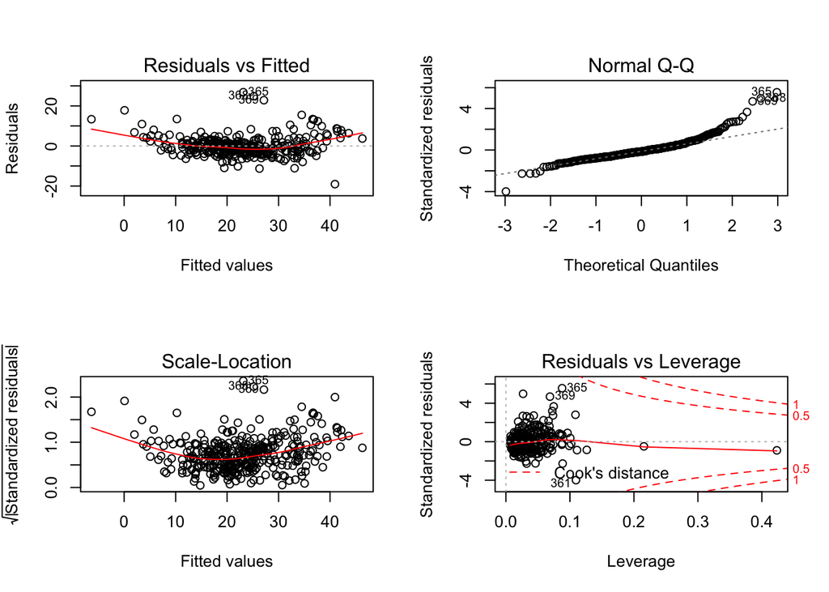

```r
par(mfrow = c(2,2))

plot(model_aic)
```

## Modifying the Model with the VIF

**Variance Inflation Factor :** ** Checking for multicollinearity through VIF.

$$VIF_{k} = \dfrac{1}{1 - R_{k}^2}$$

$R_{k}^2$ is the R^2-value obtained by regressing the kth predictor on the remaining predictors. VIF gives us an idea of multi-collinearity

- Every explanatory variable would have a VIF score
- A VIF > 4 means that there are signs of multi-collinearity and anything greater than 10 means that an explanatory variable should be dropped
- We use the “vif()” function from the car package.

```r
library(car)

vif(model_basic)
```

```
##     CRIM       ZN    INDUS     CHAS      NOX       RM      AGE      DIS
## 1.858040 2.277522 4.119690 1.069986 4.223948 2.141041 3.089053 3.987198
##      RAD      TAX       PT        B    LSTAT
## 6.430054 7.240953 1.804488 1.326867 3.163086
```

```r
vif(model_aic)
```

```
##     CRIM       ZN     CHAS      NOX       RM      DIS      RAD      TAX
## 1.848081 2.239079 1.062315 3.607357 2.012418 3.362046 5.907076 5.792799
##       PT        B    LSTAT
## 1.773052 1.322915 2.766979
```

- After applying the stepAIC, the VIF values have slightly reduced, but the variables “RAD” and “TAX” have VIF values higher than 4
- Let’s take a look at the correlation between the “RAD” and “TAX” variables

```r
cor(housing_data$RAD, housing_data$TAX,use='complete.obs')
```

```
## [1] 0.9094048
```

- The correlation coefficient is extremely high between the “RAD” and “TAX” variables
- let’s now remove the “TAX” variable, as it is the lesser significant of the two
- Build another model without the “TAX” variable, and take a look at the VIF

```r
model3 <- lm(formula = MV ~ CRIM + ZN + CHAS + NOX + RM + DIS + RAD + PT + B + LSTAT, data = train_data)
summary(model3)
```

```
##
## Call:
## lm(formula = MV ~ CRIM + ZN + CHAS + NOX + RM + DIS + RAD + PT +
##     B + LSTAT, data = train_data)
##
## Residuals:
##      Min       1Q   Median       3Q      Max
## -19.5371  -3.2149  -0.6956   1.6948  26.9730
##
## Coefficients:
##             Estimate Std. Error t value Pr(>|t|)
## (Intercept)  22.6586     0.2821  80.311  < 2e-16 ***
## CRIM         -1.1068     0.3704  -2.988 0.003016 **
## ZN            0.8487     0.4001   2.121 0.034621 *
## CHAS1         3.9957     1.1298   3.537 0.000461 ***
## NOX          -2.2605     0.5055  -4.472 1.06e-05 ***
## RM            3.3880     0.3848   8.806  < 2e-16 ***
## DIS          -2.7650     0.4957  -5.578 4.99e-08 ***
## RAD           1.3871     0.4731   2.932 0.003598 **
## PT           -1.9863     0.3591  -5.532 6.33e-08 ***
## B             1.1661     0.3123   3.734 0.000221 ***
## LSTAT        -3.7025     0.4553  -8.132 8.05e-15 ***
## ---
## Signif. codes:  0 '***' 0.001 '**' 0.01 '*' 0.05 '.' 0.1 ' ' 1
##
## Residual standard error: 5.092 on 339 degrees of freedom
## Multiple R-squared:  0.7397, Adjusted R-squared:  0.732
## F-statistic: 96.33 on 10 and 339 DF,  p-value: < 2.2e-16
```

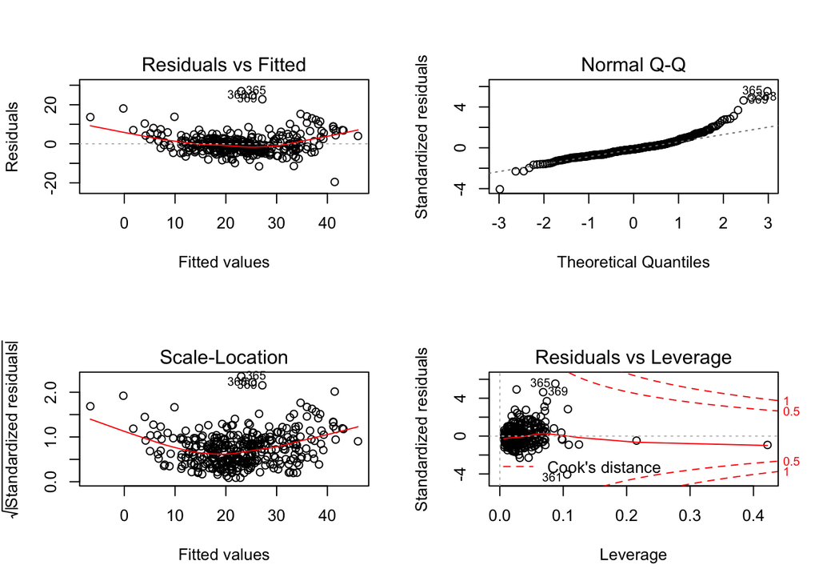

```r
par(mfrow = c(2,2))

plot(model3)
```

```r
vif(model3)
```

```
##     CRIM       ZN     CHAS      NOX       RM      DIS      RAD       PT
## 1.846878 2.154080 1.057674 3.439058 1.992382 3.307381 3.012651 1.735084
##        B    LSTAT
## 1.312561 2.790139
```

# Evaluation and Selection of Model

## Picking the Right Model

# Communication

## Prediction

Predict the Housing prices of the unseen boston housing data, using the chosen model.

```r
preds_model <- predict(model3, test_data[, !(names(test_data) %in% c("MV"))])
preds_model
```

```
##          3          8          9         10         18         20
## 31.1324916 19.7320535 21.0435324 19.0409568 16.9011074 18.0185572
##         25         26         29         30         32         33
## 15.6896328 12.8023392 19.9955936 21.3950542 18.0144036  8.3848669
##         37         40         46         48         52         62
## 21.4806433 30.7958162 21.2734325 17.7643638 23.6030665 23.9613886
##         68         69         71         73         78         89
## 21.6435981 25.7648819 24.8072272 26.6501233 23.2967021 26.2690419
##         90         91         93         96         97         98
## 28.2236154 28.1419903 28.8363081 36.4844070 33.3010797 25.6691517
##        104        110        111        112        114        119
## 17.5152369 21.3561569 21.5639839 25.9584568 24.2532126 20.2962873
##        123        126        128        129        130        132
## 20.2764960 20.0118622 21.1423950 20.4172361 21.0737794 13.3884083
##        134        145        150        151        160        164
## 16.5120866  8.4743624 15.9623705 22.9708475 41.1521572 22.3654399
##        165        178        182        186        189        198
## 26.2118058 26.2945965 23.4849108 36.0217537 34.7856630 29.6994979
##        202        205        207        214        215        216
## 22.1018378 24.4247352 23.2159473 27.8279516 25.1178003 30.2262271
##        227        231        233        234        235        236
## 23.6325679 32.7021160 31.2336661 33.1177656 28.5009464 28.6133183
##        237        239        243        252        253        254
## 27.8834009 24.3140203 20.6460256 22.4045213 37.5288885 43.6741907
##        255        262        265        266        267        273
## 35.6615241 25.9574084 38.9309870 25.8110880 21.1413467 36.9766988
##        275        278        289        291        292        294
## 29.6200539 33.7962966 30.9845706 24.3306510 28.9918437 19.5144056
##        295        296        298        302        306        311
## 29.7762556 33.2135648 29.1736726 29.3211481 24.1978015 25.5875729
##        316        321        322        327        328        330
## 21.1964971 25.1489413 24.8581761 23.5123160 20.3054388 21.7002516
##        338        340        346        353        360        362
## 31.7579009 26.7061668 24.4706920 21.4282296 21.5630204 12.1733694
##        364        371        373        376        385        386
##  8.2511812 -0.3959117 18.5375618 17.2861163  3.8571838 14.1235442
##        388        389        390        398        399        405
## 17.8690928  9.5221548 20.7736376 18.4311994 18.9664439 13.7620043
##        407        410        413        414        415        416
## 13.1240745 12.0678218 13.2947623  5.5566060  3.9850674 14.5322546
##        420        432        436        438        442        443
## 13.7492282 13.3780614 13.1649479 18.0395785 11.5919776 18.1641976
##        444        445        448        451        455        461
## 18.7100579 19.3309730 20.4307027 15.0937618 19.1708379 18.2923639
##        462        463        468        470        472        474
## 13.8161498 17.6387044 23.7453206 16.4858676 21.7298782 23.5205887
##        476        477        479        480        489        490
## 24.6892315 27.3683259 20.3626865 23.5660238 20.7417352 16.9506060
##        491        492        493        495        498        499
## 13.8725860 19.2235347 21.4896113 20.7037320 28.8201536 26.1805544
```

## Performance Metrics

Once we choose the model we have to report performance metrics on the test data. We are going to report four error metrics for regression.

### Error Metrics for Regression

- Mean Absolute Error (MAE):

$$MAE = \dfrac{1}{n}\times\sum_{i = 1}^{n}|y_{i} - \hat{y_{i}}|$$

- Mean Squared Error (MSE):

$$MSE = \dfrac{1}{n}\times\sum_{i = 1}^{n}(y_{i} - \hat{y_{i}})^2$$

- Root Mean Squared Error (RMSE):

$$RMSE = \sqrt{\dfrac{1}{n}\times\sum_{i = 1}^{n}(y_{i} - \hat{y_{i}})^2}$$

- Mean Absolute Percentage Error (MAPE):

$$MAPE = \dfrac{100}{n}\times\dfrac{\sum_{i = 1}^{n}\mid{y_{i} - \hat{y_{i}}}\mid}{y_{i}}$$

### Report Performance Metrics

- Report performance metrics obtained by using the chosen model on the test data

## Test Data

### Evaluating the Model

```r
library(DMwR)

# Error verification on train data

regr.eval(train_data$MV, model3$fitted.values)
```

```
##       mae       mse      rmse      mape
##  3.465253 25.116130  5.011600  0.174462
```

```r
# Error verification on test data

regr.eval(test_data$MV, preds_model)
```

```
##        mae        mse       rmse       mape
##  3.3425207 19.8581752  4.4562512  0.1827608
```

- Observation: Error Metrics is not far apart for train and test data after its evaluated on the third model
- Future Scope:
- 1. More models can be tried to improve Adjusted R^2
- 2. Data Transformation can be applied